# Session 4

## Import the fpp library

library(fpp)

#library(TSA)

## Example 1: CO2 Dataset

Levels of Carbon Dioxide at Alert, Canada / Time series

See ?co2 for additional information

### Plot the Time-series

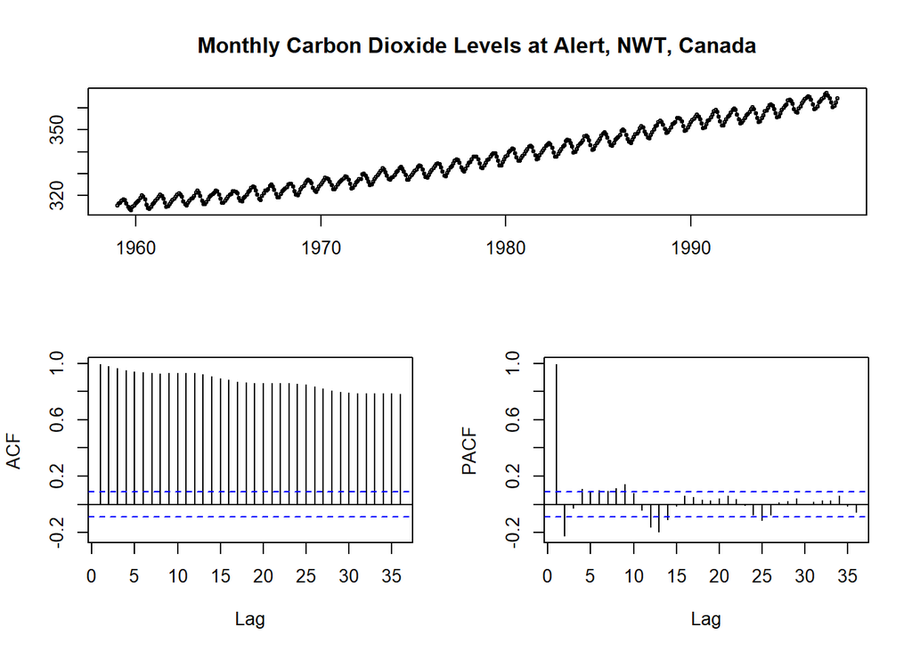

```r
win.graph(width=6, height=6,pointsize=12)
tsdisplay(co2,main='Monthly Carbon Dioxide Levels at Alert, NWT, Canada')
```

### Seasonal Difference and ACF

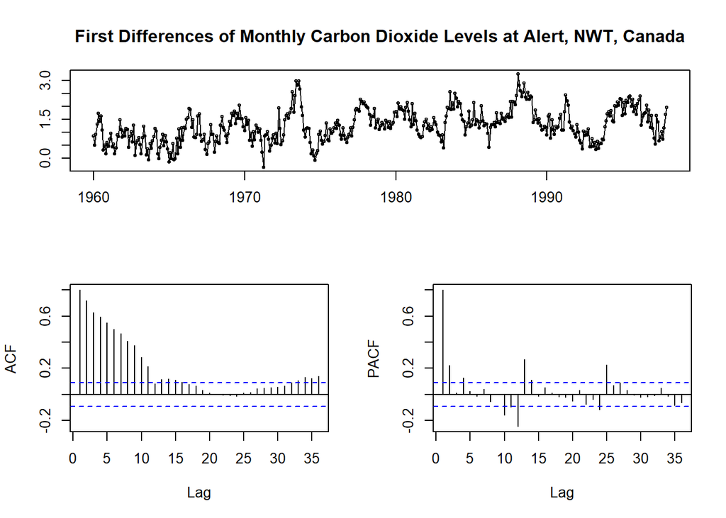

```r
co2_Seadiff <- diff(co2,lag=12)

win.graph(width=6, height=6,pointsize=12)
tsdisplay(co2_Seadiff,main='First Differences of Monthly Carbon Dioxide Levels at Alert, NWT, Canada')
```

### 1st Difference and ACF

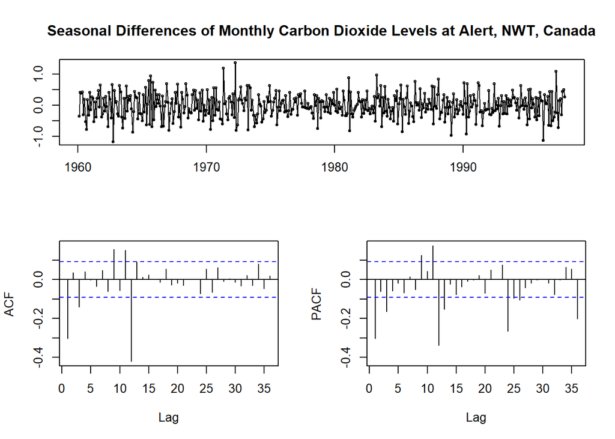

```r
co2_Seadiff_diff <- diff(co2_Seadiff)

win.graph(width=6, height=6,pointsize=12)
tsdisplay(co2_Seadiff_diff,main='Seasonal Differences of Monthly Carbon Dioxide Levels at Alert, NWT, Canada')
```

### Test for stationary

KPSS Test for Stationarity Description Computes the Kwiatkowski-Phillips-Schmidt-Shin (KPSS) test for the null hypothesis that x is level or trend stationary. See ?kpss.test() additional information

Augmented Dickey-Fuller Test Description Computes the Augmented Dickey-Fuller test for the null that x has a unit root.

See adf.test() additional information

```r
kpss.test(co2_Seadiff_diff) # p-value = 0.1 > 0.05 ==> Accept Null hypothesis ==> The process is stationary.
```

```
##
##  KPSS Test for Level Stationarity
##
## data:  co2_Seadiff_diff
## KPSS Level = 0.011476, Truncation lag parameter = 5, p-value = 0.1
```

```r
adf.test(co2_Seadiff_diff) # p-value = 0.01 < 0.05 ==> Accept alternative hypothesis ==> The process is stationary.
```

```
##
##  Augmented Dickey-Fuller Test
##
## data:  co2_Seadiff_diff
## Dickey-Fuller = -8.9846, Lag order = 7, p-value = 0.01
## alternative hypothesis: stationary
```

### Fit sArima Model (0,1,1)(0,1,1)[12]

```r
m1.co2=Arima(co2,order=c(0,1,1),seasonal=list(order=c(0,1,1),period=12))
m1.co2
```

```
## Series: co2
## ARIMA(0,1,1)(0,1,1)[12]
##
## Coefficients:
##           ma1     sma1
##       -0.3501  -0.8506
## s.e.   0.0496   0.0257
##
## sigma^2 estimated as 0.08581:  log likelihood=-86.08
## AIC=178.16   AICc=178.21   BIC=190.52
```

### Fit Arima Model using auto.arima()

#### trace - If TRUE, the list of ARIMA models considered will be reported.

See ?auto.arima() for additional information

```r
auto.arima(co2 , trace=TRUE)
```

```
##
##  Fitting models using approximations to speed things up...
##
##  ARIMA(2,1,2)(1,1,1)[12]                    : 212.1052
##  ARIMA(0,1,0)(0,1,0)[12]                    : 466.3286
##  ARIMA(1,1,0)(1,1,0)[12]                    : 325.3846
##  ARIMA(0,1,1)(0,1,1)[12]                    : 220.2612
##  ARIMA(2,1,2)(0,1,1)[12]                    : 215.0334
##  ARIMA(2,1,2)(1,1,0)[12]                    : 318.907
##  ARIMA(2,1,2)(2,1,1)[12]                    : 216.2555
##  ARIMA(2,1,2)(1,1,2)[12]                    : 200.2634
##  ARIMA(2,1,2)(0,1,2)[12]                    : 216.1603
##  ARIMA(2,1,2)(2,1,2)[12]                    : 210.3505
##  ARIMA(1,1,2)(1,1,2)[12]                    : 199.7135
##  ARIMA(1,1,2)(0,1,2)[12]                    : 224.1674
##  ARIMA(1,1,2)(1,1,1)[12]                    : 209.1014
##  ARIMA(1,1,2)(2,1,2)[12]                    : 204.2411
##  ARIMA(1,1,2)(0,1,1)[12]                    : 222.7468
##  ARIMA(1,1,2)(2,1,1)[12]                    : 211.14
##  ARIMA(0,1,2)(1,1,2)[12]                    : 200.0134
##  ARIMA(1,1,1)(1,1,2)[12]                    : 198.4585
##  ARIMA(1,1,1)(0,1,2)[12]                    : 228.9082
##  ARIMA(1,1,1)(1,1,1)[12]                    : 207.0558
##  ARIMA(1,1,1)(2,1,2)[12]                    : 203.4142
##  ARIMA(1,1,1)(0,1,1)[12]                    : 227.6893
##  ARIMA(1,1,1)(2,1,1)[12]                    : 209.4706
##  ARIMA(0,1,1)(1,1,2)[12]                    : 199.371
##  ARIMA(1,1,0)(1,1,2)[12]                    : 207.0417
##  ARIMA(2,1,1)(1,1,2)[12]                    : 202.1555
##  ARIMA(0,1,0)(1,1,2)[12]                    : 243.0949
##  ARIMA(2,1,0)(1,1,2)[12]                    : 202.2671
##
##  Now re-fitting the best model(s) without approximations...
##
##  ARIMA(1,1,1)(1,1,2)[12]                    : 180.9652
##
##  Best model: ARIMA(1,1,1)(1,1,2)[12]
```

```
## Series: co2
## ARIMA(1,1,1)(1,1,2)[12]
##
## Coefficients:
##          ar1      ma1     sar1     sma1     sma2
##       0.2569  -0.5847  -0.5489  -0.2620  -0.5123
## s.e.  0.1406   0.1204   0.5879   0.5701   0.4819
##
## sigma^2 estimated as 0.08576:  log likelihood=-84.39
## AIC=180.78   AICc=180.97   BIC=205.5
```

#### d - Order of first-differencing. If missing, will choose a value based on KPSS test.

```r
auto.arima(co2,d=1, trace=TRUE)
```

```
##
##  Fitting models using approximations to speed things up...
##
##  ARIMA(2,1,2)(1,1,1)[12]                    : 212.1052
##  ARIMA(0,1,0)(0,1,0)[12]                    : 466.3286
##  ARIMA(1,1,0)(1,1,0)[12]                    : 325.3846
##  ARIMA(0,1,1)(0,1,1)[12]                    : 220.2612
##  ARIMA(2,1,2)(0,1,1)[12]                    : 215.0334
##  ARIMA(2,1,2)(1,1,0)[12]                    : 318.907
##  ARIMA(2,1,2)(2,1,1)[12]                    : 216.2555
##  ARIMA(2,1,2)(1,1,2)[12]                    : 200.2634
##  ARIMA(2,1,2)(0,1,2)[12]                    : 216.1603
##  ARIMA(2,1,2)(2,1,2)[12]                    : 210.3505
##  ARIMA(1,1,2)(1,1,2)[12]                    : 199.7135
##  ARIMA(1,1,2)(0,1,2)[12]                    : 224.1674
##  ARIMA(1,1,2)(1,1,1)[12]                    : 209.1014
##  ARIMA(1,1,2)(2,1,2)[12]                    : 204.2411
##  ARIMA(1,1,2)(0,1,1)[12]                    : 222.7468
##  ARIMA(1,1,2)(2,1,1)[12]                    : 211.14
##  ARIMA(0,1,2)(1,1,2)[12]                    : 200.0134
##  ARIMA(1,1,1)(1,1,2)[12]                    : 198.4585
##  ARIMA(1,1,1)(0,1,2)[12]                    : 228.9082
##  ARIMA(1,1,1)(1,1,1)[12]                    : 207.0558
##  ARIMA(1,1,1)(2,1,2)[12]                    : 203.4142
##  ARIMA(1,1,1)(0,1,1)[12]                    : 227.6893
##  ARIMA(1,1,1)(2,1,1)[12]                    : 209.4706
##  ARIMA(0,1,1)(1,1,2)[12]                    : 199.371
##  ARIMA(1,1,0)(1,1,2)[12]                    : 207.0417
##  ARIMA(2,1,1)(1,1,2)[12]                    : 202.1555
##  ARIMA(0,1,0)(1,1,2)[12]                    : 243.0949
##  ARIMA(2,1,0)(1,1,2)[12]                    : 202.2671
##
##  Now re-fitting the best model(s) without approximations...
##
##  ARIMA(1,1,1)(1,1,2)[12]                    : 180.9652
##
##  Best model: ARIMA(1,1,1)(1,1,2)[12]
```

```
## Series: co2
## ARIMA(1,1,1)(1,1,2)[12]
##
## Coefficients:
##          ar1      ma1     sar1     sma1     sma2
##       0.2569  -0.5847  -0.5489  -0.2620  -0.5123
## s.e.  0.1406   0.1204   0.5879   0.5701   0.4819
##
## sigma^2 estimated as 0.08576:  log likelihood=-84.39
## AIC=180.78   AICc=180.97   BIC=205.5
```

#### allowdrift - If TRUE, models with drift terms are considered

```r
auto.arima(co2, allowdrift = FALSE, trace=TRUE)
```

```
##
##  Fitting models using approximations to speed things up...
##
##  ARIMA(2,1,2)(1,1,1)[12]                    : 212.1052
##  ARIMA(0,1,0)(0,1,0)[12]                    : 466.3286
##  ARIMA(1,1,0)(1,1,0)[12]                    : 325.3846
##  ARIMA(0,1,1)(0,1,1)[12]                    : 220.2612
##  ARIMA(2,1,2)(0,1,1)[12]                    : 215.0334
##  ARIMA(2,1,2)(1,1,0)[12]                    : 318.907
##  ARIMA(2,1,2)(2,1,1)[12]                    : 216.2555
##  ARIMA(2,1,2)(1,1,2)[12]                    : 200.2634
##  ARIMA(2,1,2)(0,1,2)[12]                    : 216.1603
##  ARIMA(2,1,2)(2,1,2)[12]                    : 210.3505
##  ARIMA(1,1,2)(1,1,2)[12]                    : 199.7135
##  ARIMA(1,1,2)(0,1,2)[12]                    : 224.1674
##  ARIMA(1,1,2)(1,1,1)[12]                    : 209.1014
##  ARIMA(1,1,2)(2,1,2)[12]                    : 204.2411
##  ARIMA(1,1,2)(0,1,1)[12]                    : 222.7468
##  ARIMA(1,1,2)(2,1,1)[12]                    : 211.14
##  ARIMA(0,1,2)(1,1,2)[12]                    : 200.0134
##  ARIMA(1,1,1)(1,1,2)[12]                    : 198.4585
##  ARIMA(1,1,1)(0,1,2)[12]                    : 228.9082
##  ARIMA(1,1,1)(1,1,1)[12]                    : 207.0558
##  ARIMA(1,1,1)(2,1,2)[12]                    : 203.4142
##  ARIMA(1,1,1)(0,1,1)[12]                    : 227.6893
##  ARIMA(1,1,1)(2,1,1)[12]                    : 209.4706
##  ARIMA(0,1,1)(1,1,2)[12]                    : 199.371
##  ARIMA(1,1,0)(1,1,2)[12]                    : 207.0417
##  ARIMA(2,1,1)(1,1,2)[12]                    : 202.1555
##  ARIMA(0,1,0)(1,1,2)[12]                    : 243.0949
##  ARIMA(2,1,0)(1,1,2)[12]                    : 202.2671
##
##  Now re-fitting the best model(s) without approximations...
##
##  ARIMA(1,1,1)(1,1,2)[12]                    : 180.9652
##
##  Best model: ARIMA(1,1,1)(1,1,2)[12]
```

```
## Series: co2
## ARIMA(1,1,1)(1,1,2)[12]
##
## Coefficients:
##          ar1      ma1     sar1     sma1     sma2
##       0.2569  -0.5847  -0.5489  -0.2620  -0.5123
## s.e.  0.1406   0.1204   0.5879   0.5701   0.4819
##
## sigma^2 estimated as 0.08576:  log likelihood=-84.39
## AIC=180.78   AICc=180.97   BIC=205.5
```

### Standardized residuals: TS plot, ACF and Hist

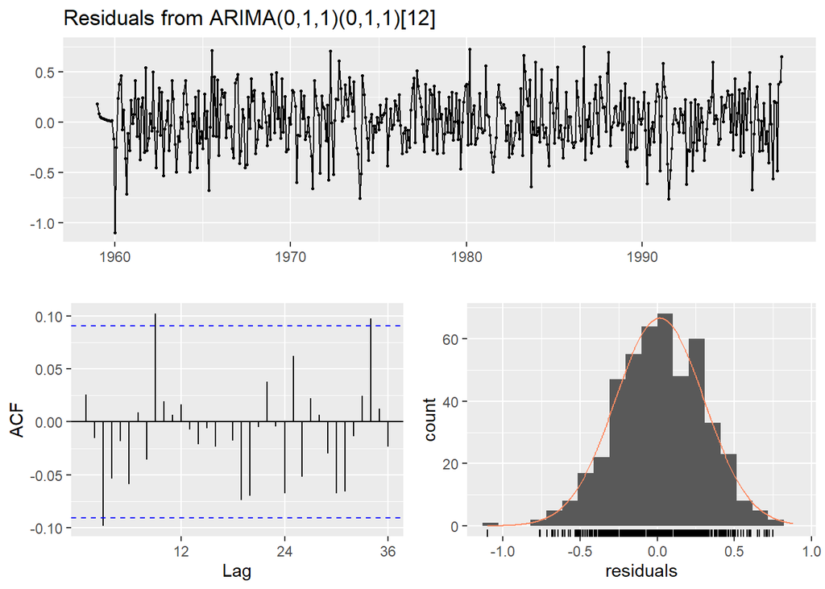

```
##
##  Ljung-Box test
##
## data:  Residuals from ARIMA(0,1,1)(0,1,1)[12]
## Q* = 22.887, df = 22, p-value = 0.4081
##
## Model df: 2.   Total lags used: 24
```

```r
# m1.co2_StdRes <- rstandard(m1.co2)

win.graph(width=6, height=6,pointsize=12)
checkresiduals(m1.co2) # p-value = 0.4081 >0.05 ==> Accept Null hypothesis ==>  The TS is independently distributed
```

### Shapiro-Wilk Normality Test

Description Performs the Shapiro-Wilk test of normality. See ?shapiro.test() for additional information

```r
shapiro.test(m1.co2$residuals) # p-value = 0.3078 > 0.05 ==> Accept Null hypothesis ==>  The TS is normally distributed
```

```
##
##  Shapiro-Wilk normality test
##
## data:  m1.co2$residuals
## W = 0.99611, p-value = 0.3078
```

### QQNorm plot

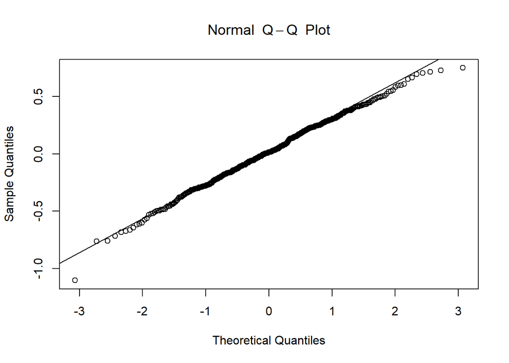

```r
qqnorm(m1.co2$residuals,main=expression(Normal~~Q-Q~~Plot))
qqline(m1.co2$residuals)
```

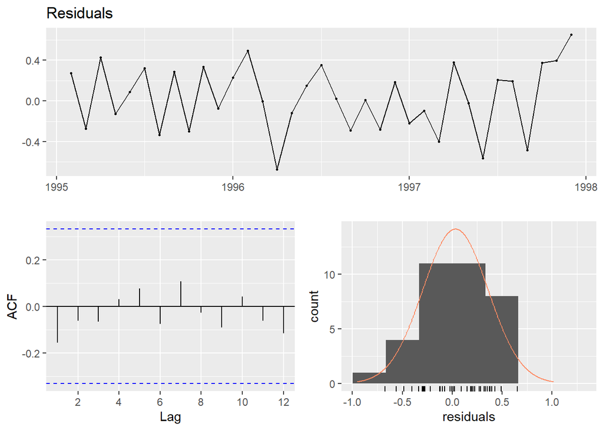

```r
Res_sub <-window(m1.co2$residuals,start=c(1995,2))

checkresiduals(Res_sub)
```

```r
shapiro.test(Res_sub) # p-value = 0.5401 >0.05 ==> Accept Null hypothesis ==>  The TS came from a normally distributed population
```

```
##
##  Shapiro-Wilk normality test
##
## data:  Res_sub
## W = 0.9733, p-value = 0.5401
```

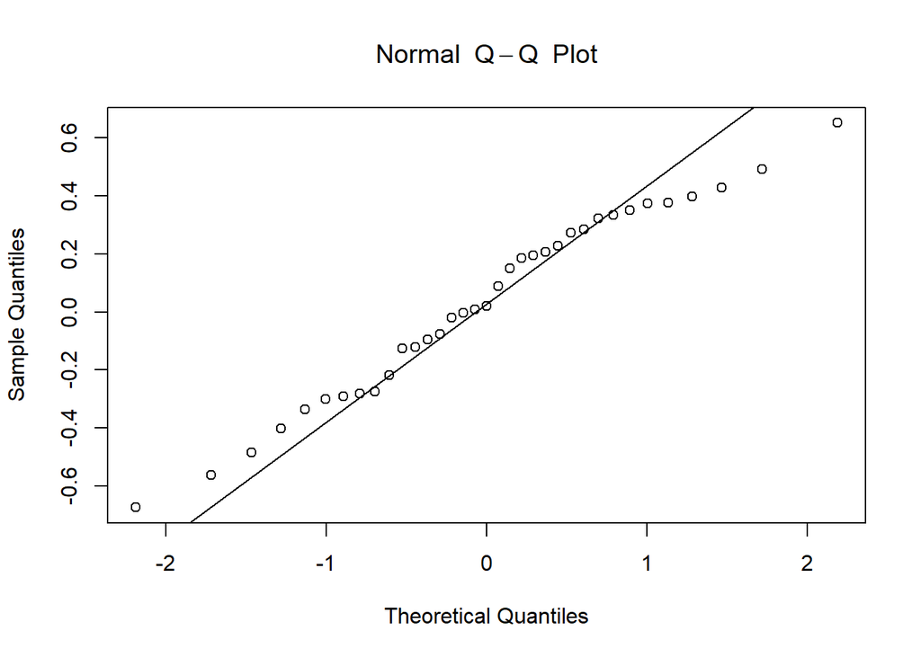

```r
qqnorm(Res_sub,main=expression(Normal~~Q-Q~~Plot))
qqline(Res_sub)
```

### Ljung-Box test

Description Compute the Box-Pierce or Ljung-Box test statistic for examining the null hypothesis of independence in a given time series. These are sometimes known as ‘portmanteau’ tests

See ?Box.test() for additional information

```r
Box.test(Res_sub, type =  "Ljung-Box") # p-value = 0.3372 >0.05 ==> Accept Null hypothesis ==>  The TS is independently distributed
```

```
##
##  Box-Ljung test
##
## data:  Res_sub
## X-squared = 0.92119, df = 1, p-value = 0.3372
```

### Jarque-Bera Test

Description Tests the null of normality for x using the Jarque-Bera test statistic

See ?jarque.bera.test() for additional information

```r
jarque.bera.test(m1.co2$residuals) # p-value = 0.2619 >0.05 ==> ==> Accept Null hypothesis ==>  The sample data have the skewness and kurtosis matching a normal distribution
```

```
##
##  Jarque Bera Test
##
## data:  m1.co2$residuals
## X-squared = 2.6795, df = 2, p-value = 0.2619
```

### Fit sArima Model (0,1,2)(0,1,1)[12]

```r
m2.co2=Arima(co2,order=c(0,1,2),seasonal=list(order=c(0,1,1),period=12))
m2.co2
```

```
## Series: co2
## ARIMA(0,1,2)(0,1,1)[12]
##
## Coefficients:
##           ma1      ma2     sma1
##       -0.3436  -0.0492  -0.8499
## s.e.   0.0473   0.0475   0.0256
##
## sigma^2 estimated as 0.08582:  log likelihood=-85.55
## AIC=179.09   AICc=179.18   BIC=195.57
```

#### Discussion:

##### Series: co2

##### ARIMA(0,1,1)(0,1,1)[12]

##### Coefficients:

##### ma1 sma1

##### -0.3501 -0.8506

##### s.e. 0.0496 0.0257

##### sigma^2 estimated as 0.08581: log likelihood=-86.08

##### AIC=178.16 AICc=178.21 BIC=190.52

When we compare these results with those reported in above, we see that the estimates of Theta_1 and Theta_Seas have changed very little-especially when the size of the standard errors is taken into consideration. In addition, the estimate of the new parameter, Theta_2, is not statistically different from zero. Note also that the estimate and the log-likelihood have not changed much while the AIC has actually increased.